# DATA607 Final Project: Air Quality and Rent Prices

Cunyverse: Javern Wilson, Mia Siracusa, Kleber Perez, Yohannes Deboch

May 8, 2019

```r
library(tidyverse)
library(reshape2)
library(kableExtra)
library(rvest)
library(XML)
library(RCurl)
library(tm)
library(DT)
library(pdftools)
library(gridExtra)
```

## Introduction

Air quality serves as an important indicator for monitoring progress toward achieving a sustainable and healthy future. Enhancements in air quality are a direct indication of achievements in sustainable energy, urban development, and infrastructure. On the contrary, exposure to dangerous air pollutants can lead to chronic diseases, such as asthma, especially in children. We are interested in exploring the relationship between air quality and rent prices of NYC neighborhoods.

## Import and Clean

At first the [Air_Quality](https://github.com/javernw/DATA607GroupProjects/blob/master/Final%20Project/Air_Quality.csv) data is read into R. Any rows that are not completed is removed. For this project, we will only focus on the boroughs and the neighborhoods within. UHF42 (United Hospital Fund) consist of 42 neighborhoods ajoining zip codes areas, designated to approximate New York City Community Planning Districts.

```r
air_quality <- read.csv("https://raw.githubusercontent.com/javernw/DATA607GroupProjects/master/Final%20Project/Air_Quality.csv", header = T, stringsAsFactors = F) #Air_Quality.csv
air_q <- air_quality #use a secondary variable for analysis
air_q <- air_q[complete.cases(air_q), ] #only keep full rows

#columns not needed for analysis is removed
air_q <- air_q %>%  select(-indicator_data_id, -indicator_id, -year_description)
air_q <- filter(air_q, geo_type_name == c("UHF42"))
```

## Scraping

In order to match rent prices to the respective neighborhoods, we decided to get the data from [Apartments.com](https://www.apartments.com/). The prices taken from the website differs everyday so the information scraped were collected and stored into .CSV files for accuracy and stability.

#### Collect Zipcode and Matching Neighborhood with [UHF42 Code](https://www.health.ny.gov/statistics/cancer/registry/appendix/neighborhoods.htm)

```r
link <- "https://www.health.ny.gov/statistics/cancer/registry/appendix/neighborhoods.htm"

zip_table <- link %>% read_html() %>% html_nodes("table") %>% html_table(fill = T) %>% data.frame(stringsAsFactors = F)

#add UHF42 Neighborhood code (Ncode) column
zip_table$NCode <- c(105, 103, 106, 107, 101, 102, 104, 203, 209, 206, 208, 210, 202, 207, 204, 201, 205, 211, 302, 306, 303, 307, 308, 310, 309, 305, 304, 301, 404, 403, 406, 408, 401, 405, 410, 409, 407, 402, 501, 503, 502, 504)

#re-arrange columns
zip_table <- zip_table[, c(1,4,2,3)]

kable(zip_table) %>% kable_styling(font_size = 10) %>% scroll_box(height = "500px", width = "350px")
```

| Borough | NCode | Neighborhood | ZIP.Codes |
| --- | --- | --- | --- |
| Bronx | 105 | Central Bronx | 10453, 10457, 10460 |
| Bronx | 103 | Bronx Park and Fordham | 10458, 10467, 10468 |
| Bronx | 106 | High Bridge and Morrisania | 10451, 10452, 10456 |
| Bronx | 107 | Hunts Point and Mott Haven | 10454, 10455, 10459, 10474 |
| Bronx | 101 | Kingsbridge and Riverdale | 10463, 10471 |
| Bronx | 102 | Northeast Bronx | 10466, 10469, 10470, 10475 |
| Bronx | 104 | Southeast Bronx | 10461, 10462,10464, 10465, 10472, 10473 |
| Brooklyn | 203 | Central Brooklyn | 11212, 11213, 11216, 11233, 11238 |
| Brooklyn | 209 | Southwest Brooklyn | 11209, 11214, 11228 |
| Brooklyn | 206 | Borough Park | 11204, 11218, 11219, 11230 |
| Brooklyn | 208 | Canarsie and Flatlands | 11234, 11236, 11239 |
| Brooklyn | 210 | Southern Brooklyn | 11223, 11224, 11229, 11235 |
| Brooklyn | 202 | Northwest Brooklyn | 11201, 11205, 11215, 11217, 11231 |
| Brooklyn | 207 | Flatbush | 11203, 11210, 11225, 11226 |
| Brooklyn | 204 | East New York and New Lots | 11207, 11208 |
| Brooklyn | 201 | Greenpoint | 11211, 11222 |
| Brooklyn | 205 | Sunset Park | 11220, 11232 |
| Brooklyn | 211 | Bushwick and Williamsburg | 11206, 11221, 11237 |
| Manhattan | 302 | Central Harlem | 10026, 10027, 10030, 10037, 10039 |
| Manhattan | 306 | Chelsea and Clinton | 10001, 10011, 10018, 10019, 10020, 10036 |
| Manhattan | 303 | East Harlem | 10029, 10035 |
| Manhattan | 307 | Gramercy Park and Murray Hill | 10010, 10016, 10017, 10022 |
| Manhattan | 308 | Greenwich Village and Soho | 10012, 10013, 10014 |
| Manhattan | 310 | Lower Manhattan | 10004, 10005, 10006, 10007, 10038, 10280 |
| Manhattan | 309 | Lower East Side | 10002, 10003, 10009 |
| Manhattan | 305 | Upper East Side | 10021, 10028, 10044, 10065, 10075, 10128 |
| Manhattan | 304 | Upper West Side | 10023, 10024, 10025 |
| Manhattan | 301 | Inwood and Washington Heights | 10031, 10032, 10033, 10034, 10040 |
| Queens | 404 | Northeast Queens | 11361, 11362, 11363, 11364 |
| Queens | 403 | North Queens | 11354, 11355, 11356, 11357, 11358, 11359, 11360 |
| Queens | 406 | Central Queens | 11365, 11366, 11367 |
| Queens | 408 | Jamaica | 11412, 11423, 11432, 11433, 11434, 11435, 11436 |
| Queens | 401 | Northwest Queens | 11101, 11102, 11103, 11104, 11105, 11106 |
| Queens | 405 | West Central Queens | 11374, 11375, 11379, 11385 |
| Queens | 410 | Rockaways | 11691, 11692, 11693, 11694, 11695, 11697 |
| Queens | 409 | Southeast Queens | 11004, 11005, 11411, 11413, 11422, 11426, 11427, 11428, 11429 |
| Queens | 407 | Southwest Queens | 11414, 11415, 11416, 11417, 11418, 11419, 11420, 11421 |
| Queens | 402 | West Queens | 11368, 11369, 11370, 11372, 11373, 11377, 11378 |
| Staten Island | 501 | Port Richmond | 10302, 10303, 10310 |
| Staten Island | 503 | South Shore | 10306, 10307, 10308, 10309, 10312 |
| Staten Island | 502 | Stapleton and St. George | 10301, 10304, 10305 |
| Staten Island | 504 | Mid-Island | 10314 |

#### Collect Rent Prices for each Neighborhood and Borough from Apartments.com

```r
### Bronx

bronx_url<-paste0("https://www.apartments.com/bronx-ny/", 1:20)

bronx <- lapply(bronx_url,
                function(pg){
                  pg %>% read_html() %>%
                    html_nodes("#placards") %>%
                    html_text() %>%
                    str_extract_all("\\$\\d.\\d+")
                })
bronx <- parse_number(unlist(bronx))

Bxurl1 <- "https://www.apartments.com/mount-hope-bronx-ny/"
central_bronx <- Bxurl1 %>% read_html() %>%  html_node("#placards") %>%
    html_text() %>% str_extract_all("\\$\\d.\\d+") %>% unlist() %>% parse_number()%>% mean()

Bxurl2 <- "https://www.apartments.com/fordham-heights-bronx-ny/"
fordham <- Bxurl2 %>% read_html() %>%  html_node("#placards") %>%
    html_text() %>% str_extract_all("\\$\\d.\\d+") %>% unlist() %>% parse_number()%>% mean()

Bxurl3 <- "https://www.apartments.com/highbridge-bronx-ny/"
high_bridge <- Bxurl3 %>% read_html() %>%  html_node("#placards") %>%
    html_text() %>% str_extract_all("\\$\\d.\\d+") %>% unlist() %>% parse_number()%>% mean()%>% mean()

Bxurl4 <- "https://www.apartments.com/mount-hope-bronx-ny/"
huntspoint <- Bxurl4 %>% read_html() %>%  html_node("#placards") %>%
    html_text() %>% str_extract_all("\\$\\d.\\d+") %>% unlist() %>% parse_number()%>% mean()

Bxurl5 <- "https://www.apartments.com/kingsbridge-bronx-ny/"
kingsbridge <- Bxurl5 %>% read_html() %>%  html_node("#placards") %>%
    html_text() %>% str_extract_all("\\$\\d.\\d+") %>% unlist() %>% parse_number()%>% mean()

Bxurl6 <- "https://www.apartments.com/mount-hope-bronx-ny/"
north_eastbx <- Bxurl6 %>% read_html() %>%  html_node("#placards") %>%
    html_text() %>% str_extract_all("\\$\\d.\\d+") %>% unlist() %>% parse_number()%>% mean()

Bxurl7 <- "https://www.apartments.com/parkchester-bronx-ny/"
south_eastbx <- Bxurl7 %>% read_html() %>%  html_node("#placards") %>%
    html_text() %>% str_extract_all("\\$\\d.\\d+") %>% unlist() %>% parse_number()%>% mean()


####Brooklyn


brooklyn_url<-paste0("https://www.apartments.com/brooklyn-ny/", 1:20)

brooklyn <- lapply(brooklyn_url,
                function(pg){
                  pg %>% read_html() %>%
                    html_nodes("#placards") %>%
                    html_text() %>%
                    str_extract_all("\\$\\d.\\d+")
                })
brooklyn <- parse_number(unlist(brooklyn))

Burl1 <- "https://www.apartments.com/crown-heights-brooklyn-ny/"
central_brooklyn <- Burl1 %>% read_html() %>%  html_node("#placards") %>%
    html_text() %>% str_extract_all("\\$\\d.\\d+") %>% unlist() %>% parse_number() %>% mean()

Burl2 <- "https://www.apartments.com/southwest-brooklyn-brooklyn-ny/"
sw_brooklyn <- Burl2 %>% read_html() %>%  html_node("#placards") %>%
    html_text() %>% str_extract_all("\\$\\d.\\d+") %>% unlist() %>% parse_number()%>% mean()

Burl3 <- "https://www.apartments.com/borough-park-brooklyn-ny/"
borough_park <- Burl3 %>% read_html() %>%  html_node("#placards") %>%
    html_text() %>% str_extract_all("\\$\\d.\\d+") %>% unlist() %>% parse_number()%>% mean()

Burl4 <- "https://www.apartments.com/flatlands-brooklyn-ny/"
canarsie_flatlands <- Burl4 %>% read_html() %>%  html_node("#placards") %>%
    html_text() %>% str_extract_all("\\$\\d.\\d+") %>% unlist() %>% parse_number()%>% mean()

Burl5 <- "https://www.apartments.com/coney-island-brooklyn-ny/"
south_brooklyn <- Burl5 %>% read_html() %>%  html_node("#placards") %>%
    html_text() %>% str_extract_all("\\$\\d.\\d+") %>% unlist() %>% parse_number()%>% mean()

Burl6 <- "https://www.apartments.com/park-slope-brooklyn-ny/?bb=62kx98lnvHihhqwB"
nw_brooklyn <- Burl6 %>% read_html() %>%  html_node("#placards") %>%
    html_text() %>% str_extract_all("\\$\\d.\\d+") %>% unlist() %>% parse_number()%>% mean()

Burl7 <- "https://www.apartments.com/flatbush-brooklyn-ny/"
flatbush <- Burl7 %>% read_html() %>%  html_node("#placards") %>%
    html_text() %>% str_extract_all("\\$\\d.\\d+") %>% unlist() %>% parse_number()%>% mean()

Burl8 <- "https://www.apartments.com/east-new-york-brooklyn-ny/"
east_ny <- Burl8 %>% read_html() %>%  html_node("#placards") %>%
    html_text() %>% str_extract_all("\\$\\d.\\d+") %>% unlist() %>% parse_number()%>% mean()

Burl9 <- "https://www.apartments.com/greenpoint-brooklyn-ny/"
greenpoint <- Burl9 %>% read_html() %>%  html_node("#placards") %>%
    html_text() %>% str_extract_all("\\$\\d.\\d+") %>% unlist() %>% parse_number()%>% mean()

Burl10 <- "https://www.apartments.com/sunset-park-brooklyn-ny/"
sunset_park<- Burl10 %>% read_html() %>%  html_node("#placards") %>%
    html_text() %>% str_extract_all("\\$\\d.\\d+") %>% unlist() %>% parse_number()%>% mean()

Burl11 <- "https://www.apartments.com/bushwick-brooklyn-ny/"
bushwick <- Burl11 %>% read_html() %>%  html_node("#placards") %>%
    html_text() %>% str_extract_all("\\$\\d.\\d+") %>% unlist() %>% parse_number()%>% mean()



#### Manhattan

manhattan_url <-paste0("https://www.apartments.com/manhattan-ny/", 1:20)

manhattan <- lapply(manhattan_url,
                function(pg){
                  pg %>% read_html() %>%
                    html_nodes("#placards") %>%
                    html_text() %>%
                    str_extract_all("\\$\\d.\\d+")
                })
manhattan <- parse_number(unlist(manhattan))

Murl1 <- "https://www.apartments.com/central-harlem-new-york-ny/"
central_harlem <- Murl1 %>% read_html() %>%  html_node("#placards") %>%
    html_text() %>% str_extract_all("\\$\\d.\\d+") %>% unlist() %>% parse_number()%>% mean()

Murl2 <- "https://www.apartments.com/chelsea-new-york-ny/"
chelsea_clinton <- Murl2 %>% read_html() %>%  html_node("#placards") %>%
    html_text() %>% str_extract_all("\\$\\d.\\d+") %>% unlist() %>% parse_number()%>% mean()

Murl3 <- "https://www.apartments.com/east-harlem-new-york-ny/"
east_harlem <- Murl3 %>% read_html() %>%  html_node("#placards") %>%
    html_text() %>% str_extract_all("\\$\\d.\\d+") %>% unlist() %>% parse_number()%>% mean()

Murl4 <- "https://www.apartments.com/gramercy-park-new-york-ny/"
gramercy_murray <- Murl4 %>% read_html() %>%  html_node("#placards") %>%
    html_text() %>% str_extract_all("\\$\\d.\\d+") %>% unlist() %>% parse_number()%>% mean()

Murl5 <- "https://www.apartments.com/greenwich-village-new-york-ny/"
greenwich_soho <- Murl5 %>% read_html() %>%  html_node("#placards") %>%
    html_text() %>% str_extract_all("\\$\\d.\\d+") %>% unlist() %>% parse_number()%>% mean()

Murl6 <- "https://www.apartments.com/lower-manhattan-new-york-ny/"
lower_manhattan <- Murl6 %>% read_html() %>%  html_node("#placards") %>%
    html_text() %>% str_extract_all("\\$\\d.\\d+") %>% unlist() %>% parse_number()%>% mean()

Murl7 <- "https://www.apartments.com/lower-east-side-new-york-ny/"
lower_east <- Murl7 %>% read_html() %>%  html_node("#placards") %>%
    html_text() %>% str_extract_all("\\$\\d.\\d+") %>% unlist() %>% parse_number()%>% mean()

Murl8 <- "https://www.apartments.com/upper-east-side-new-york-ny/"
upper_east <- Murl8 %>% read_html() %>%  html_node("#placards") %>%
    html_text() %>% str_extract_all("\\$\\d.\\d+") %>% unlist() %>% parse_number()%>% mean()

Murl9 <- "https://www.apartments.com/upper-west-side-new-york-ny/"
upper_west <- Murl9 %>% read_html() %>%  html_node("#placards") %>%
    html_text() %>% str_extract_all("\\$\\d.\\d+") %>% unlist() %>% parse_number()%>% mean()

Murl10 <- "https://www.apartments.com/washington-heights-new-york-ny/"
inwood_washington <- Murl10 %>% read_html() %>%  html_node("#placards") %>%
    html_text() %>% str_extract_all("\\$\\d.\\d+") %>% unlist() %>% parse_number()%>% mean()

### Queens

queens_url <-paste0("https://www.apartments.com/queens-ny/", 1:20)

queens <- lapply(queens_url,
                function(pg){
                  pg %>% read_html() %>%
                    html_nodes("#placards") %>%
                    html_text() %>%
                    str_extract_all("\\$\\d.\\d+")
                })
queens <- parse_number(unlist(queens))

Qurl1 <- "https://www.apartments.com/northeast-queens-flushing-ny/"
north_east <- Qurl1 %>% read_html() %>%  html_node("#placards") %>%
    html_text() %>% str_extract_all("\\$\\d.\\d+") %>% unlist() %>% parse_number()%>% mean()

Qurl2 <- "https://www.apartments.com/bayside-ny/"
north <- Qurl2 %>% read_html() %>%  html_node("#placards") %>%
    html_text() %>% str_extract_all("\\$\\d.\\d+") %>% unlist() %>% parse_number()%>% mean()

Qurl3 <- "https://www.apartments.com/central-queens-queens-ny/"
central <- Qurl3 %>% read_html() %>%  html_node("#placards") %>%
    html_text() %>% str_extract_all("\\$\\d.\\d+") %>% unlist() %>% parse_number()%>% mean()

Qurl4 <- "https://www.apartments.com/southeast-queens-jamaica-ny/"
jamaica <- Qurl4 %>% read_html() %>%  html_node("#placards") %>%
    html_text() %>% str_extract_all("\\$\\d.\\d+") %>% unlist() %>% parse_number()%>% mean()

Qurl5 <- "https://www.apartments.com/long-island-city-ny/"
north_west <- Qurl5 %>% read_html() %>%  html_node("#placards") %>%
    html_text() %>% str_extract_all("\\$\\d.\\d+") %>% unlist() %>% parse_number()%>% mean()

Qurl6 <- "https://www.apartments.com/forest-hills-ny/"
west_central <- Qurl6 %>% read_html() %>%  html_node("#placards") %>%
    html_text() %>% str_extract_all("\\$\\d.\\d+") %>% unlist() %>% parse_number()%>% mean()

Qurl7 <- "https://www.apartments.com/south-shore-queens-far-rockaway-ny/"
rockaway <- Qurl7 %>% read_html() %>%  html_node("#placards") %>%
    html_text() %>% str_extract_all("\\$\\d.\\d+") %>% unlist() %>% parse_number()%>% mean()

Qurl8 <- "https://www.apartments.com/hollis-ny/"
south_east <- Qurl8 %>% read_html() %>%  html_node("#placards") %>%
    html_text() %>% str_extract_all("\\$\\d.\\d+") %>% unlist() %>% parse_number()%>% mean()

Qurl9 <- "https://www.apartments.com/howard-beach-ny/"
south_west <- Qurl9 %>% read_html() %>%  html_node("#placards") %>%
    html_text() %>% str_extract_all("\\$\\d.\\d+") %>% unlist() %>% parse_number()%>% mean()

Qurl10<- "https://www.apartments.com/northeast-queens-flushing-ny/"
west <- Qurl10 %>% read_html() %>%  html_node("#placards") %>%
    html_text() %>% str_extract_all("\\$\\d.\\d+") %>% unlist() %>% parse_number()%>% mean()



#### Staten Island

SI_url <-paste0("https://www.apartments.com/staten-island-ny/", 1:20)

Staten_Island <- lapply(SI_url,
                function(pg){
                  pg %>% read_html() %>%
                    html_nodes("#placards") %>%
                    html_text() %>%
                    str_extract_all("\\$\\d.\\d+")
                })
Staten_Island <- parse_number(unlist(Staten_Island))

Surl1 <- "https://www.apartments.com/port-richmond-staten-island-ny/"
port_richmond <- Surl1 %>% read_html() %>%  html_node("#placards") %>%
    html_text() %>% str_extract_all("\\$\\d.\\d+") %>% unlist() %>% parse_number()%>% mean()

Surl2 <- "https://www.apartments.com/stapleton-staten-island-ny/"
stapleton <- Surl2 %>% read_html() %>%  html_node("#placards") %>%
    html_text() %>% str_extract_all("\\$\\d.\\d+") %>% unlist() %>% parse_number()%>% mean()

Surl3 <- "https://www.apartments.com/staten-island-ny-10306/"
south_shore <- Surl3 %>% read_html() %>%  html_node("#placards") %>%
    html_text() %>% str_extract_all("\\$\\d.\\d+") %>% unlist() %>% parse_number()%>% mean()

Surl4 <- "https://www.apartments.com/staten-island-ny-10314/"
mid_island <- Surl4 %>% read_html() %>%  html_node("#placards") %>%
    html_text() %>% str_extract_all("\\$\\d.\\d+") %>% unlist() %>% parse_number()%>% mean()
```

#### Collect Neighborhood and Matching UHF42 Code from pdf file on web

```r
file <- 'http://a816-dohbesp.nyc.gov/IndicatorPublic/EPHTPDF/uhf42.pdf'


text <- pdf_text(file)
text2 <- strsplit(text, "\n")
uhf42_codes <- text2 %>%
  str_extract_all(pattern = "\\d{3}") %>%
  unlist() %>%
  parse_number() %>%
  unique() %>%
 sort()
uhf42_names <- gsub("NYC UHF 42 Neighborhoods", "", text2)
uhf42_names <- gsub("UHF Neighborhood Name", "", uhf42_names)
uhf42_names <- gsub("UHF Code", "", uhf42_names)
uhf42_names <- gsub("Neighborhood Definition:.+", "", uhf42_names)
uhf42_names <- gsub("\\d{3}", "", uhf42_names)
uhf42_names <- unlist(str_extract_all(uhf42_names, "(\\s[A-Za-z]+.\\-?.[A-Za-z]+.\\-?.[A-Za-z]+.[A-Za-z]+.\\-?.[A-Za-z]+| Jamaica| Rockaway| Sunset Park)"))
uhf42_names <- gsub("\\\\r", "", uhf42_names)

neighborhood <- data.frame(Code = uhf42_codes, Location = uhf42_names, stringsAsFactors = F)

kable(neighborhood) %>% kable_styling(font_size = 12) %>% scroll_box(height = "500px", width = "300px")
```

| Code | Location |
| --- | --- |
| 101 | Kingsbridge - Riverdale |
| 102 | Northeast Bronx |
| 103 | Fordham - Bronx Park |
| 104 | Pelham - Throgs Neck |
| 105 | Crotona - Tremont |
| 106 | High Bridge - Morrisania |
| 107 | Hunts Point - Mott Haven |
| 201 | Greenpoint |
| 202 | Downtown - Heights - Slope |
| 203 | Bedford Stuyvesant - Crown Heights |
| 204 | East New York |
| 205 | Sunset Park |
| 206 | Borough Park |
| 207 | East Flatbush - Flatbush |
| 208 | Canarsie - Flatlands |
| 209 | Bensonhurst - Bay Ridge |
| 210 | Coney Island - Sheepshead Bay |
| 211 | Williamsburg - Bushwick |
| 301 | Washington Heights - Inwood |
| 302 | Central Harlem - Morningside Heights |
| 303 | East Harlem |
| 304 | Upper West Side |
| 305 | Upper East Side |
| 306 | Chelsea - Clinton |
| 307 | Gramercy Park - Murray Hill |
| 308 | Greenwich Village - Soho |
| 309 | Union Square - Lower East Side |
| 310 | Lower Manhattan |
| 401 | Long Island City - Astoria |
| 402 | West Queens |
| 403 | Flushing - Clearview |
| 404 | Bayside - Little Neck |
| 405 | Ridgewood - Forest Hills |
| 406 | Fresh Meadows |
| 407 | Southwest Queens |
| 408 | Jamaica |
| 409 | Southeast Queens |
| 410 | Rockaway |
| 501 | Port Richmond |
| 502 | Stapleton - St. George |
| 503 | Willowbrook |
| 504 | South Beach - Tottenville |

```r
#write.csv(neighborhood, file = "Neighborhood.csv", row.names = F)
```

#### UHF42 Codes and Rent Prices

```r
Rent_prices <- c(central_bronx, fordham, high_bridge, huntspoint, kingsbridge, north_eastbx, south_eastbx, central_brooklyn, sw_brooklyn, borough_park, canarsie_flatlands, south_brooklyn, nw_brooklyn, flatbush, east_ny, greenpoint, sunset_park, bushwick, central_harlem, chelsea_clinton, east_harlem, gramercy_murray, greenwich_soho, lower_manhattan, lower_east, upper_east, upper_west, inwood_washington, north_east, north, central, jamaica, north_west, west_central, rockaway, south_east, south_west, west, port_richmond, stapleton, south_shore, mid_island)


rent <- data.frame(UHF42Code = zip_table$NCode, avg_Rentprice = Rent_prices, stringsAsFactors = F)

#write.csv(rent, file = "Rent.csv", row.names = F) #store file

kable(rent) %>% kable_styling(font_size = 12) %>% scroll_box(height = "500px", width = "250px")
```

| UHF42Code | avg_Rentprice |
| --- | --- |
| 105 | 1683.625 |
| 103 | 1624.762 |
| 106 | 1954.421 |
| 107 | 1683.625 |
| 101 | 2190.600 |
| 102 | 1683.625 |
| 104 | 1624.375 |
| 203 | 2218.800 |
| 209 | 2034.960 |
| 206 | 2160.476 |
| 208 | 2270.320 |
| 210 | 2200.391 |
| 202 | 3558.333 |
| 207 | 2301.400 |
| 204 | 2222.792 |
| 201 | 2854.348 |
| 205 | 2111.217 |
| 211 | 1924.458 |
| 302 | 2753.480 |
| 306 | 3761.880 |
| 303 | 2543.320 |
| 307 | 3776.080 |
| 308 | 3856.458 |
| 310 | 3502.375 |
| 309 | 4014.880 |
| 305 | 3635.760 |
| 304 | 3498.478 |
| 301 | 2325.400 |
| 404 | 1980.360 |
| 403 | 2301.538 |
| 406 | 2111.292 |
| 408 | 1797.040 |
| 401 | 2570.414 |
| 405 | 2053.269 |
| 410 | 1833.292 |
| 409 | 2535.115 |
| 407 | 2130.455 |
| 402 | 1980.360 |
| 501 | 1800.000 |
| 503 | 1439.500 |
| 502 | 2202.000 |
| 504 | 2385.000 |

#### Add the average rent prices to the Air Quality dataset

```r
air_rent <- inner_join(air_q, rent, by = c("geo_entity_id" = "UHF42Code"))

#rename columns
names(air_rent) <- c("TypeofToxin", "Unitofmeasurement", "LocationType", "UHF42Code", "Location", "Measurement", "avg_Rentprice")

#write.csv(air_rent, file = "Air_Rent.csv", row.names = F)

kable(head(air_rent, 30)) %>% kable_styling(font_size = 10) %>% scroll_box(height = "500px")
```

| TypeofToxin | Unitofmeasurement | LocationType | UHF42Code | Location | Measurement | avg_Rentprice |
| --- | --- | --- | --- | --- | --- | --- |
| Air Toxics Concentrations- Average Benzene Concentrations | Average Concentration | UHF42 | 101 | Kingsbridge - Riverdale | 2.9 | 2190.600 |
| Air Toxics Concentrations- Average Benzene Concentrations | Average Concentration | UHF42 | 102 | Northeast Bronx | 2.8 | 1683.625 |
| Air Toxics Concentrations- Average Benzene Concentrations | Average Concentration | UHF42 | 103 | Fordham - Bronx Pk | 2.7 | 1624.762 |
| Air Toxics Concentrations- Average Benzene Concentrations | Average Concentration | UHF42 | 104 | Pelham - Throgs Neck | 2.7 | 1624.375 |
| Air Toxics Concentrations- Average Benzene Concentrations | Average Concentration | UHF42 | 105 | Crotona -Tremont | 3.0 | 1683.625 |
| Air Toxics Concentrations- Average Benzene Concentrations | Average Concentration | UHF42 | 106 | High Bridge - Morrisania | 3.0 | 1954.421 |
| Air Toxics Concentrations- Average Benzene Concentrations | Average Concentration | UHF42 | 107 | Hunts Point - Mott Haven | 2.8 | 1683.625 |
| Air Toxics Concentrations- Average Benzene Concentrations | Average Concentration | UHF42 | 201 | Greenpoint | 3.7 | 2854.348 |
| Air Toxics Concentrations- Average Benzene Concentrations | Average Concentration | UHF42 | 202 | Downtown - Heights - Slope | 3.7 | 3558.333 |
| Air Toxics Concentrations- Average Benzene Concentrations | Average Concentration | UHF42 | 203 | Bedford Stuyvesant - Crown Heights | 2.5 | 2218.800 |
| Air Toxics Concentrations- Average Benzene Concentrations | Average Concentration | UHF42 | 204 | East New York | 2.3 | 2222.792 |
| Air Toxics Concentrations- Average Benzene Concentrations | Average Concentration | UHF42 | 205 | Sunset Park | 3.2 | 2111.217 |
| Air Toxics Concentrations- Average Benzene Concentrations | Average Concentration | UHF42 | 206 | Borough Park | 2.5 | 2160.476 |
| Air Toxics Concentrations- Average Benzene Concentrations | Average Concentration | UHF42 | 207 | East Flatbush - Flatbush | 2.3 | 2301.400 |
| Air Toxics Concentrations- Average Benzene Concentrations | Average Concentration | UHF42 | 208 | Canarsie - Flatlands | 2.4 | 2270.320 |
| Air Toxics Concentrations- Average Benzene Concentrations | Average Concentration | UHF42 | 209 | Bensonhurst - Bay Ridge | 2.8 | 2034.960 |
| Air Toxics Concentrations- Average Benzene Concentrations | Average Concentration | UHF42 | 210 | Coney Island - Sheepshead Bay | 2.4 | 2200.391 |
| Air Toxics Concentrations- Average Benzene Concentrations | Average Concentration | UHF42 | 211 | Williamsburg - Bushwick | 2.8 | 1924.458 |
| Air Toxics Concentrations- Average Benzene Concentrations | Average Concentration | UHF42 | 301 | Washington Heights | 4.1 | 2325.400 |
| Air Toxics Concentrations- Average Benzene Concentrations | Average Concentration | UHF42 | 302 | Central Harlem - Morningside Heights | 3.9 | 2753.480 |
| Air Toxics Concentrations- Average Benzene Concentrations | Average Concentration | UHF42 | 303 | East Harlem | 4.2 | 2543.320 |
| Air Toxics Concentrations- Average Benzene Concentrations | Average Concentration | UHF42 | 304 | Upper West Side | 3.9 | 3498.478 |
| Air Toxics Concentrations- Average Benzene Concentrations | Average Concentration | UHF42 | 305 | Upper East Side | 4.5 | 3635.760 |
| Air Toxics Concentrations- Average Benzene Concentrations | Average Concentration | UHF42 | 306 | Chelsea - Clinton | 4.9 | 3761.880 |
| Air Toxics Concentrations- Average Benzene Concentrations | Average Concentration | UHF42 | 307 | Gramercy Park - Murray Hill | 5.3 | 3776.080 |
| Air Toxics Concentrations- Average Benzene Concentrations | Average Concentration | UHF42 | 308 | Greenwich Village - SoHo | 4.7 | 3856.458 |
| Air Toxics Concentrations- Average Benzene Concentrations | Average Concentration | UHF42 | 309 | Union Square - Lower East Side | 5.0 | 4014.880 |
| Air Toxics Concentrations- Average Benzene Concentrations | Average Concentration | UHF42 | 310 | Lower Manhattan | 6.3 | 3502.375 |
| Air Toxics Concentrations- Average Benzene Concentrations | Average Concentration | UHF42 | 401 | Long Island City - Astoria | 2.7 | 2570.414 |
| Air Toxics Concentrations- Average Benzene Concentrations | Average Concentration | UHF42 | 402 | West Queens | 2.2 | 1980.360 |

The air quality data concentrates on nine major air pollutants

```r
airq_cat <- air_rent %>% select(TypeofToxin) %>% distinct()

kable(airq_cat) %>% kable_styling(bootstrap_options = "striped" ,font_size = 11) %>% scroll_box(height = "500px")
```

| TypeofToxin |
| --- |
| Air Toxics Concentrations- Average Benzene Concentrations |
| Air Toxics Concentrations- Average Formaldehyde Concentrations |
| Boiler Emissions- Total NOx Emissions |
| Boiler Emissions- Total PM2.5 Emissions |
| Boiler Emissions- Total SO2 Emissions |
| Neighborhood Air Quality Concentrations- Elemental Carbon (EC) |
| Neighborhood Air Quality Concentrations- Fine Particulate Matter (PM2.5) |
| Neighborhood Air Quality Concentrations- Nitric Oxide (NO) |
| Neighborhood Air Quality Concentrations- Nitrogen Dioxide (NO2) |
| Neighborhood Air Quality Concentrations- Ozone (O3) |
| Neighborhood Air Quality Concentrations: Sulfur Dioxide (SO2) |
| O3-Attributable Asthma ED Visits |
| O3-Attributable Asthma Hospitalizations |
| O3-Attributable Cardiac and Respiratory Deaths |
| PM2.5-Attributable Asthma ED Visits |
| PM2.5-Attributable Cardiovascular Hospitalizations (Adults 40 Yrs and Older) |
| PM2.5-Attributable Deaths |
| PM2.5-Attributable Respiratory Hospitalizations (Adults 20 Yrs and Older) |
| Traffic Density- Annual Vehicle Miles Traveled (VMT) |
| Traffic Density- Annual Vehicle Miles Traveled (VMT) for Cars |
| Traffic Density- Annual Vehicle Miles Traveled (VMT) for Trucks |

We will focus on these two: $PM2.5$ and $O_3$ for this project.

Background:

- $PM2.5$ - Particular Matter.

A mixture of solids and liquids floating in the air. PM2.5 substances can travel deep into our lungs and reach the bloodstream. Numerous studies have linked particulate matter exposure to decreased lung function, respiratory symptoms like coughing and labored breathing, and even reduced life expectancy. The [U.S. Environmental Protection Agency (EPA)](https://www3.epa.gov/region1/eco/uep/particulatematter.html) divides particulate matter sources into two categories: primary and secondary. Primary particles come directly from a source, such as agriculture and construction sites. Secondary particles form when gases from burning fuels react with sunlight and water vapor.

- $O_3$ - Ozone

A triatomic form of oxygen that can be harmful to one’s health. When inhaled, ozone can damage the lungs. Small amounts when breathe in can cause chest pain, coughing, shortness of breath and lung irritation. Ozone may also worsen chronic respiratory diseases such as asthma and compromise the ability of the body to fight respiratory infections.

```r
air_rent2 <- air_rent %>% filter(TypeofToxin %in% c("O3-Attributable Asthma ED Visits","O3-Attributable Asthma Hospitalizations ", "O3-Attributable Cardiac and Respiratory Deaths ", "PM2.5-Attributable Asthma ED Visits ", "PM2.5-Attributable Cardiovascular Hospitalizations (Adults 40 Yrs and Older) ", "PM2.5-Attributable Deaths ", "PM2.5-Attributable Respiratory Hospitalizations (Adults 20 Yrs and Older)"))

kable(air_rent2) %>% kable_styling(bootstrap_options = "striped" ,font_size = 10) %>% scroll_box(height = "500px")
```

| TypeofToxin | Unitofmeasurement | LocationType | UHF42Code | Location | Measurement | avg_Rentprice |
| --- | --- | --- | --- | --- | --- | --- |
| O3-Attributable Asthma ED Visits | Rate- 18 Yrs and Older | UHF42 | 101 | Kingsbridge - Riverdale | 30.1 | 2190.600 |
| O3-Attributable Asthma ED Visits | Rate- 18 Yrs and Older | UHF42 | 101 | Kingsbridge - Riverdale | 30.1 | 2190.600 |
| O3-Attributable Asthma ED Visits | Rate- Children 0 to 17 Yrs Old | UHF42 | 101 | Kingsbridge - Riverdale | 68.3 | 2190.600 |
| O3-Attributable Asthma ED Visits | Rate- Children 0 to 17 Yrs Old | UHF42 | 101 | Kingsbridge - Riverdale | 68.3 | 2190.600 |
| O3-Attributable Asthma ED Visits | Rate- 18 Yrs and Older | UHF42 | 102 | Northeast Bronx | 58.3 | 1683.625 |
| O3-Attributable Asthma ED Visits | Rate- 18 Yrs and Older | UHF42 | 102 | Northeast Bronx | 58.3 | 1683.625 |
| O3-Attributable Asthma ED Visits | Rate- Children 0 to 17 Yrs Old | UHF42 | 102 | Northeast Bronx | 114.5 | 1683.625 |
| O3-Attributable Asthma ED Visits | Rate- Children 0 to 17 Yrs Old | UHF42 | 102 | Northeast Bronx | 114.5 | 1683.625 |
| O3-Attributable Asthma ED Visits | Rate- 18 Yrs and Older | UHF42 | 103 | Fordham - Bronx Pk | 84.1 | 1624.762 |
| O3-Attributable Asthma ED Visits | Rate- 18 Yrs and Older | UHF42 | 103 | Fordham - Bronx Pk | 84.1 | 1624.762 |
| O3-Attributable Asthma ED Visits | Rate- Children 0 to 17 Yrs Old | UHF42 | 103 | Fordham - Bronx Pk | 115.8 | 1624.762 |
| O3-Attributable Asthma ED Visits | Rate- Children 0 to 17 Yrs Old | UHF42 | 103 | Fordham - Bronx Pk | 115.8 | 1624.762 |
| O3-Attributable Asthma ED Visits | Rate- 18 Yrs and Older | UHF42 | 104 | Pelham - Throgs Neck | 64.8 | 1624.375 |
| O3-Attributable Asthma ED Visits | Rate- 18 Yrs and Older | UHF42 | 104 | Pelham - Throgs Neck | 64.8 | 1624.375 |
| O3-Attributable Asthma ED Visits | Rate- Children 0 to 17 Yrs Old | UHF42 | 104 | Pelham - Throgs Neck | 114.6 | 1624.375 |
| O3-Attributable Asthma ED Visits | Rate- Children 0 to 17 Yrs Old | UHF42 | 104 | Pelham - Throgs Neck | 114.6 | 1624.375 |
| O3-Attributable Asthma ED Visits | Rate- 18 Yrs and Older | UHF42 | 105 | Crotona -Tremont | 138.6 | 1683.625 |
| O3-Attributable Asthma ED Visits | Rate- 18 Yrs and Older | UHF42 | 105 | Crotona -Tremont | 138.6 | 1683.625 |
| O3-Attributable Asthma ED Visits | Rate- Children 0 to 17 Yrs Old | UHF42 | 105 | Crotona -Tremont | 159.6 | 1683.625 |
| O3-Attributable Asthma ED Visits | Rate- Children 0 to 17 Yrs Old | UHF42 | 105 | Crotona -Tremont | 159.6 | 1683.625 |
| O3-Attributable Asthma ED Visits | Rate- 18 Yrs and Older | UHF42 | 106 | High Bridge - Morrisania | 124.0 | 1954.421 |
| O3-Attributable Asthma ED Visits | Rate- 18 Yrs and Older | UHF42 | 106 | High Bridge - Morrisania | 124.0 | 1954.421 |
| O3-Attributable Asthma ED Visits | Rate- Children 0 to 17 Yrs Old | UHF42 | 106 | High Bridge - Morrisania | 171.2 | 1954.421 |
| O3-Attributable Asthma ED Visits | Rate- Children 0 to 17 Yrs Old | UHF42 | 106 | High Bridge - Morrisania | 171.2 | 1954.421 |
| O3-Attributable Asthma ED Visits | Rate- 18 Yrs and Older | UHF42 | 107 | Hunts Point - Mott Haven | 130.1 | 1683.625 |
| O3-Attributable Asthma ED Visits | Rate- 18 Yrs and Older | UHF42 | 107 | Hunts Point - Mott Haven | 130.1 | 1683.625 |
| O3-Attributable Asthma ED Visits | Rate- Children 0 to 17 Yrs Old | UHF42 | 107 | Hunts Point - Mott Haven | 169.4 | 1683.625 |
| O3-Attributable Asthma ED Visits | Rate- Children 0 to 17 Yrs Old | UHF42 | 107 | Hunts Point - Mott Haven | 169.4 | 1683.625 |
| O3-Attributable Asthma ED Visits | Rate- 18 Yrs and Older | UHF42 | 201 | Greenpoint | 27.0 | 2854.348 |
| O3-Attributable Asthma ED Visits | Rate- 18 Yrs and Older | UHF42 | 201 | Greenpoint | 27.0 | 2854.348 |

[output cut: 1650 more lines]

## Exploration

#### Various rent prices within the cities

```r
cities <- list(bronx, brooklyn, manhattan, queens, Staten_Island)

city_rent <- as.data.frame(lapply(cities, `length<-`, max(lengths(cities))))

names(city_rent) <- c("Bronx", "Brooklyn", "Manhattan", "Queens", "Staten_Island")

kable(head(city_rent, 20)) %>% kable_styling(font_size = 11) %>% scroll_box(height = "500px")
```

| Bronx | Brooklyn | Manhattan | Queens | Staten_Island |
| --- | --- | --- | --- | --- |
| 1499 | 2800 | 2169 | 2169 | 1850 |
| 1500 | 2598 | 3923 | 2600 | 1595 |
| 1895 | 3350 | 2600 | 1400 | 1795 |
| 2595 | 2871 | 2675 | 3407 | 1855 |
| 1560 | 2475 | 3407 | 1725 | 1395 |
| 1700 | 2400 | 4000 | 2871 | 925 |
| 1675 | 3975 | 3188 | 2741 | 1189 |
| 1750 | 2765 | 2997 | 1490 | 1795 |
| 1299 | 1420 | 3490 | 1975 | 1420 |
| 1575 | 1800 | 4225 | 2400 | 1645 |
| 1725 | 1590 | 3750 | 1599 | 1850 |
| 1425 | 2700 | 3410 | 2000 | 1500 |
| 2350 | 3600 | 3845 | 1995 | 1250 |
| 1700 | 1695 | 2672 | 2819 | 724 |
| 1700 | 1475 | 2871 | 2805 | 825 |
| 2500 | 1875 | 4703 | 2650 | 746 |
| 3150 | 2575 | 3175 | 1475 | 1800 |
| 1775 | 2745 | 3295 | 1475 | 3100 |
| 1950 | 2535 | 2741 | 1600 | 2200 |
| 1800 | 3195 | 1499 | 1599 | 2350 |

```r
summary(city_rent)
```

```
##      Bronx         Brooklyn      Manhattan        Queens
##  Min.   :1000   Min.   : 700   Min.   :1000   Min.   : 700
##  1st Qu.:1600   1st Qu.:1500   1st Qu.:1900   1st Qu.:1500
##  Median :1948   Median :2095   Median :2650   Median :1999
##  Mean   :2043   Mean   :2079   Mean   :2864   Mean   :2007
##  3rd Qu.:2380   3rd Qu.:2560   3rd Qu.:3450   3rd Qu.:2400
##  Max.   :9900   Max.   :6923   Max.   :9900   Max.   :5100
##  NA's   :62     NA's   :1      NA's   :63
##  Staten_Island
##  Min.   : 724
##  1st Qu.:1100
##  Median :1500
##  Mean   :1590
##  3rd Qu.:2000
##  Max.   :3300
##  NA's   :344
```

##### Transform `city_rent` to long format to do analysis among boroughs

```r
city_rent2 <- gather(city_rent, key = "City", value = "Rent")

head(city_rent2)
```

```
##    City Rent
## 1 Bronx 1499
## 2 Bronx 1500
## 3 Bronx 1895
## 4 Bronx 2595
## 5 Bronx 1560
## 6 Bronx 1700
```

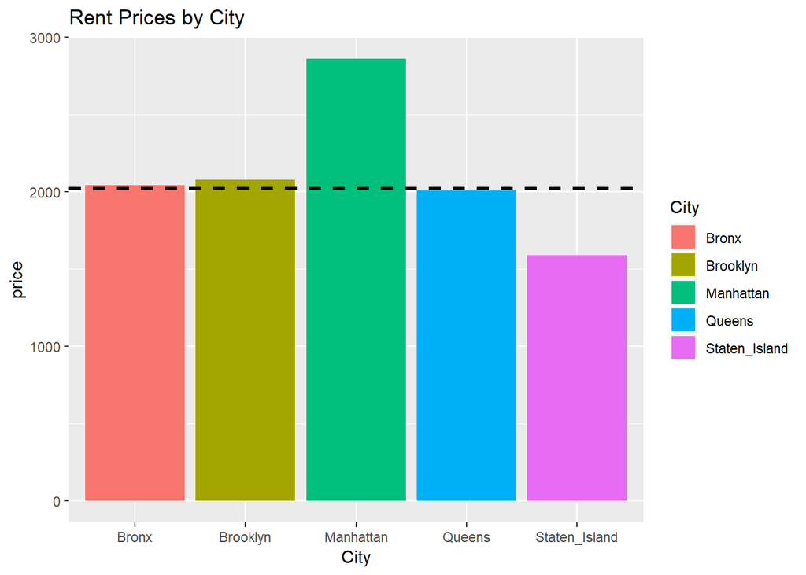

```r
median_rent = median(city_rent2$Rent, na.rm = T)

city_rent2 %>%
  group_by(City) %>%
  summarise(price = mean(Rent, na.rm = T)) %>%
  ggplot(aes(x = City, y = price, fill = City)) +
  geom_bar(stat = "identity", size = 1) +
  geom_hline(yintercept = median_rent , size = 1, linetype = 2) + labs(title = "Rent Prices by City")
```

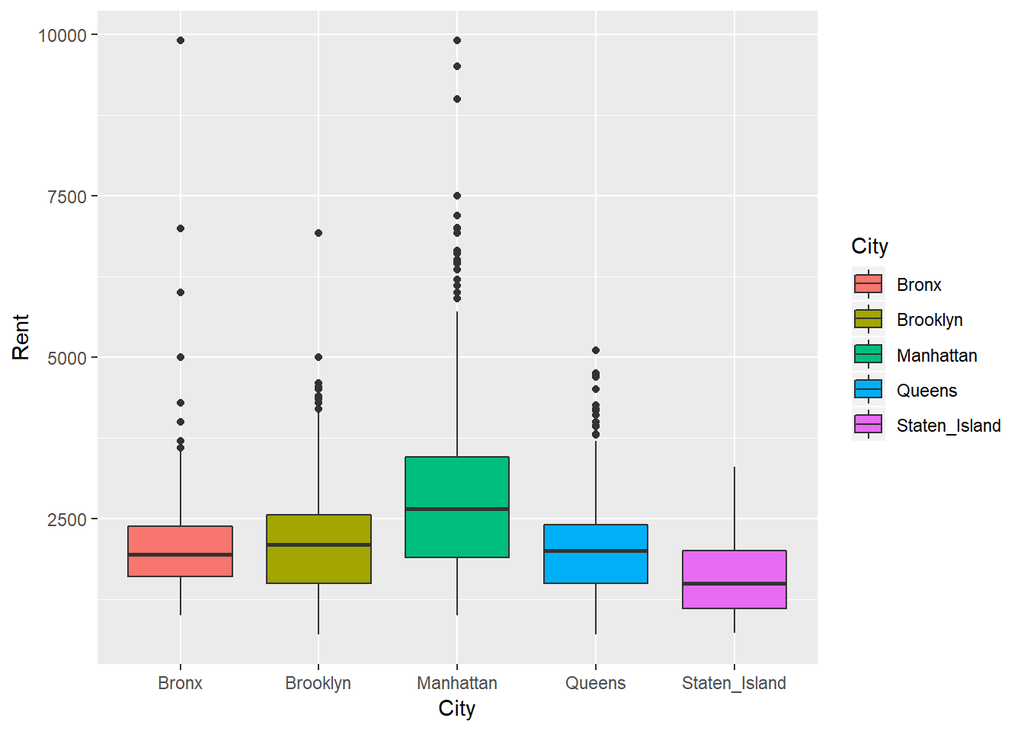

```r
city_rent2 %>% ggplot(aes(x = City, y = Rent, fill = City)) + geom_boxplot()
```

Highlights:

- Staten Island had the least reported rent prices and has **cheapest** rent
- Manhattan is the **most expensive** city to live in with NY
- Queens is the largest city and has the **most reported prices** but they prices are lower than Manhattan, Bronx and Brooklyn.
- According to this [census](https://www.citypopulation.de/php/usa-newyorkcity.php) as of 2018, Brooklyn is the **most popuated city** in NY. If you look at the boxplot, you find that the outliers for Brooklyn are not as extreme. This could mean that rent prices are very competitive hence the ranges are close to each other.

##### Rent prices

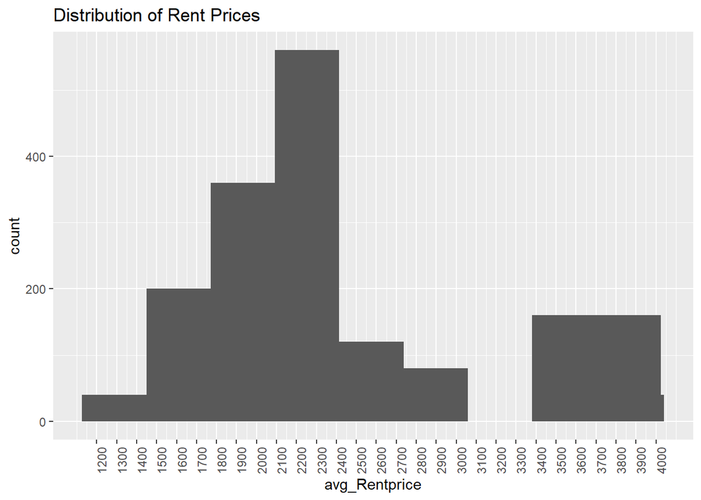

```r
ggplot(air_rent2, aes(x = avg_Rentprice)) + geom_histogram() + stat_bin(bins = 9) + ggtitle("Distribution of Rent Prices") + scale_x_continuous(breaks = seq(1200, 4000, 100)) + theme(axis.text.x = element_text(angle = 90, hjust = 1))
```

The distributin is positively skewed which corroborates with the fact that some folks, not too much, pay more than the average for rent.

##### Which Toxin does more damage?

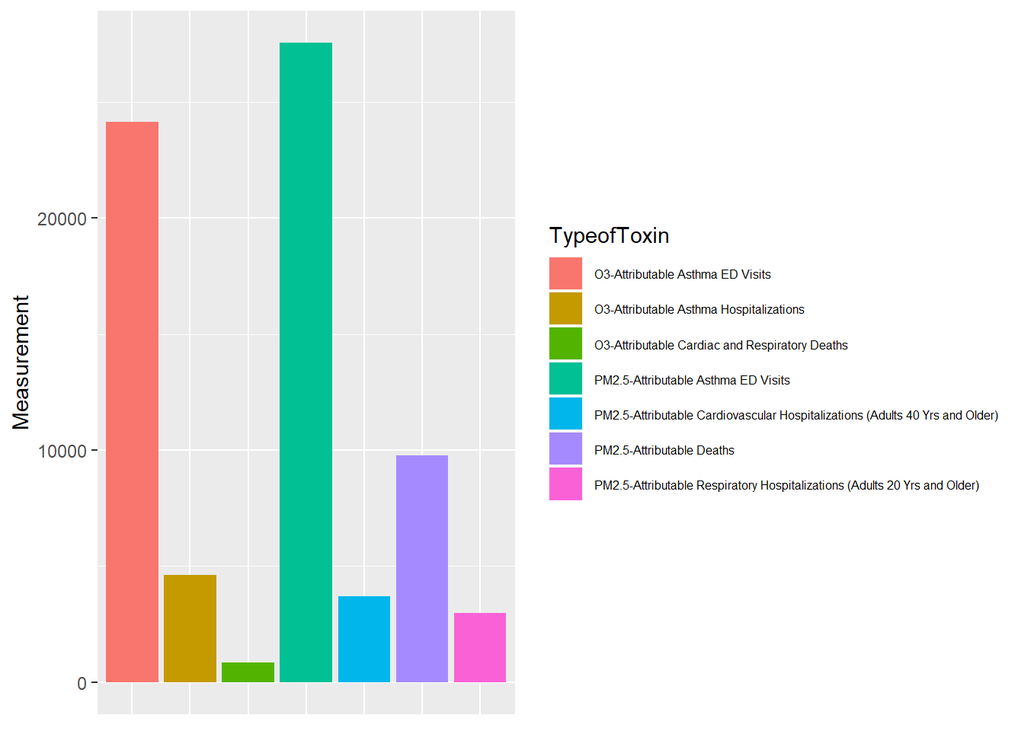

```r
air_rent2 %>% ggplot(aes(x = TypeofToxin, y = Measurement, fill = TypeofToxin)) + geom_bar(stat = "identity") +
  theme(axis.title.x=element_blank(),
        axis.text.x=element_blank(),
        axis.ticks.x=element_blank()) +
  theme(legend.text = element_text(size=6))
```

##### Which group is affected the most?

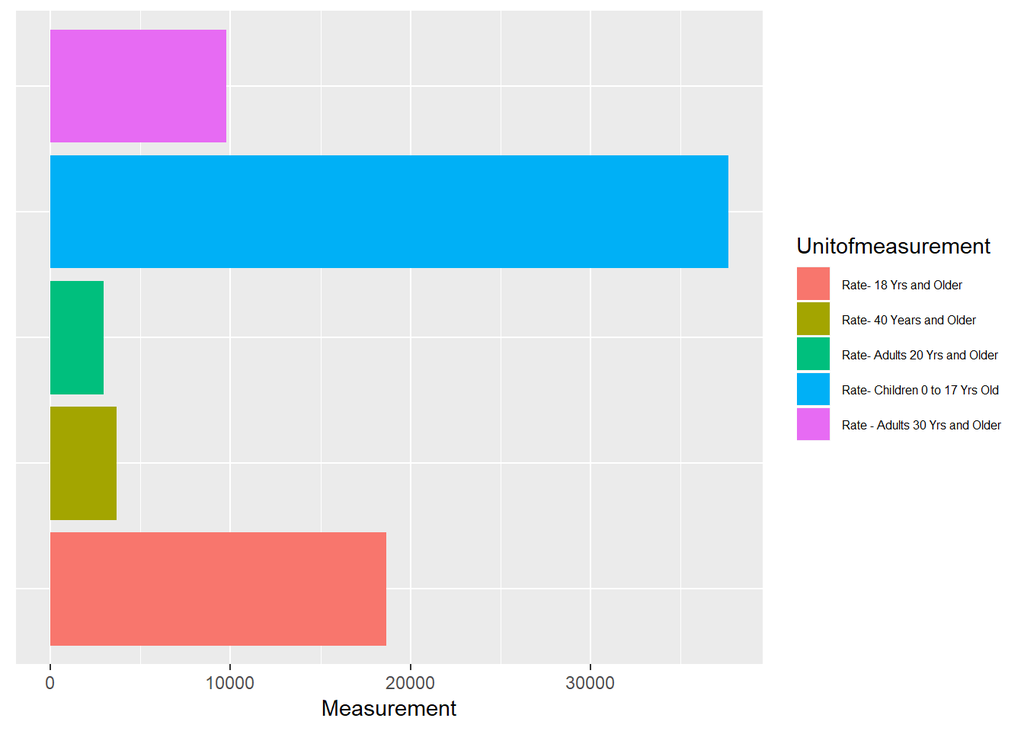

```r
air_rent2 %>% filter(!Unitofmeasurement == "Rate") %>% ggplot(aes(x = Unitofmeasurement, y = Measurement, fill = Unitofmeasurement)) + geom_bar(stat = "identity") +
  theme(axis.title.y =element_blank(),
        axis.text.y =element_blank(),
        axis.ticks.y =element_blank()) +
  theme(legend.text = element_text(size=6)) + coord_flip()
```

Group mostly affected by these toxin especially particular matter, are the kids between ages 0-17, which is plausibe as their bodies are not as immune to the pollutants as the adults. Least affected are those persons in their 20’s.

##### Asthma Hospitalization related to Ozone

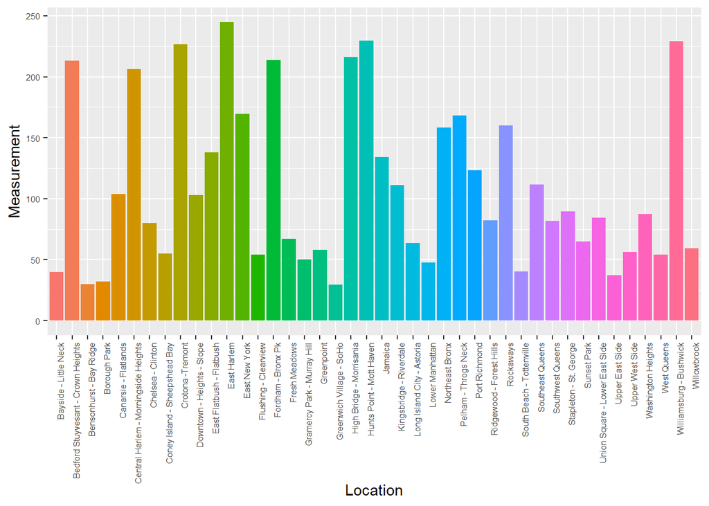

```r
air_rent2 %>% filter(TypeofToxin == "O3-Attributable Asthma Hospitalizations ") %>% ggplot(aes(x = Location, y = Measurement, fill = Location)) + geom_bar(stat = "identity") + theme(legend.position = "none") + theme(axis.text.x = element_text(angle = 90, hjust = 1)) + theme(axis.text=element_text(size=6))
```

East Harlem has the highest ozone count responsible for Asthma hospitalizations.

##### Asthma Attacks due to Particular Matter

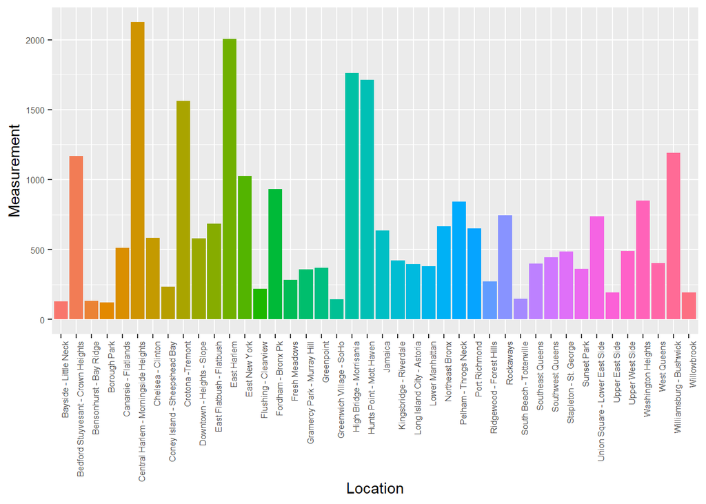

```r
air_rent2 %>% filter(TypeofToxin == "PM2.5-Attributable Asthma ED Visits ") %>% ggplot(aes(x = Location, y = Measurement, fill = Location)) + geom_bar(stat = "identity") + theme(legend.position = "none") + theme(axis.text.x = element_text(angle = 90, hjust = 1)) + theme(axis.text=element_text(size=6))
```

##### Median cost of rent in these neighborhoods under these type of toxins.

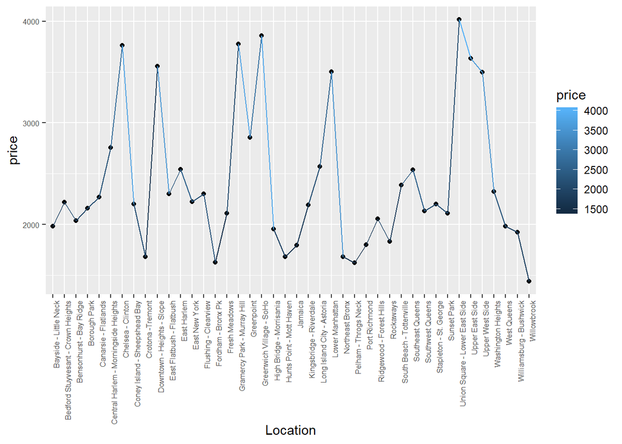

```r
air_rent2 %>% group_by(Location) %>% summarise(price = median(avg_Rentprice)) %>% ggplot(aes(x = Location, y = price, fill = price, group = 1)) + geom_point() + geom_line(aes(color = price)) + theme(axis.text.x = element_text(angle = 90, hjust = 1)) + theme(axis.text=element_text(size=6))
```

## Statistical Analysis

Is there a relationship between higher rent prices and lower pollution factors in NYC neighborhoods? We can check by running a linear regression model.

```r
#
plot(air_rent2$avg_Rentprice ~ air_rent2$Measurement)
obs <- lm(air_rent2$avg_Rentprice ~ air_rent2$Measurement)

summary(obs)
```

```
##
## Call:
## lm(formula = air_rent2$avg_Rentprice ~ air_rent2$Measurement)
##
## Residuals:
##     Min      1Q  Median      3Q     Max
## -1031.0  -471.6  -222.7   214.9  1780.1
##
## Coefficients:
##                        Estimate Std. Error t value Pr(>|t|)
## (Intercept)           2476.5879    22.0722  112.20   <2e-16 ***
## air_rent2$Measurement   -1.5916     0.3242   -4.91    1e-06 ***
## ---
## Signif. codes:  0 '***' 0.001 '**' 0.01 '*' 0.05 '.' 0.1 ' ' 1
##
## Residual standard error: 692.9 on 1678 degrees of freedom
## Multiple R-squared:  0.01416,    Adjusted R-squared:  0.01358
## F-statistic: 24.11 on 1 and 1678 DF,  p-value: 9.999e-07
```

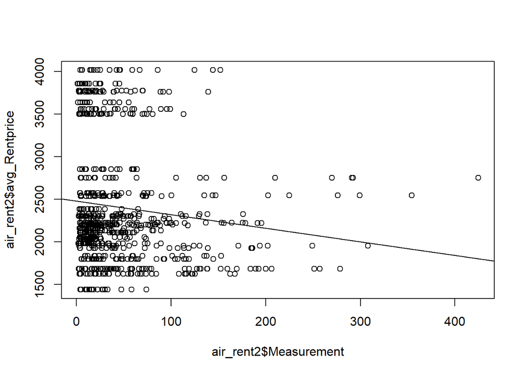

```r
abline(obs)
```

Let’s have a closer look at two areas:

O3-Attributable Asthma ED Visits

```r
df2 <- filter(air_rent2, TypeofToxin == "O3-Attributable Asthma ED Visits")
plot(df2$avg_Rentprice ~ df2$Measurement)
obs2 <- lm(df2$avg_Rentprice ~ df2$Measurement)
summary(obs2)
```

```
##
## Call:
## lm(formula = df2$avg_Rentprice ~ df2$Measurement)
##
## Residuals:
##     Min      1Q  Median      3Q     Max
## -1102.1  -485.9  -227.4   317.8  1782.7
##
## Coefficients:
##                  Estimate Std. Error t value Pr(>|t|)
## (Intercept)     2580.8261    60.4455  42.697  < 2e-16 ***
## df2$Measurement   -2.4212     0.6609  -3.664 0.000289 ***
## ---
## Signif. codes:  0 '***' 0.001 '**' 0.01 '*' 0.05 '.' 0.1 ' ' 1
##
## Residual standard error: 685.9 on 334 degrees of freedom
## Multiple R-squared:  0.03863,    Adjusted R-squared:  0.03575
## F-statistic: 13.42 on 1 and 334 DF,  p-value: 0.0002891
```

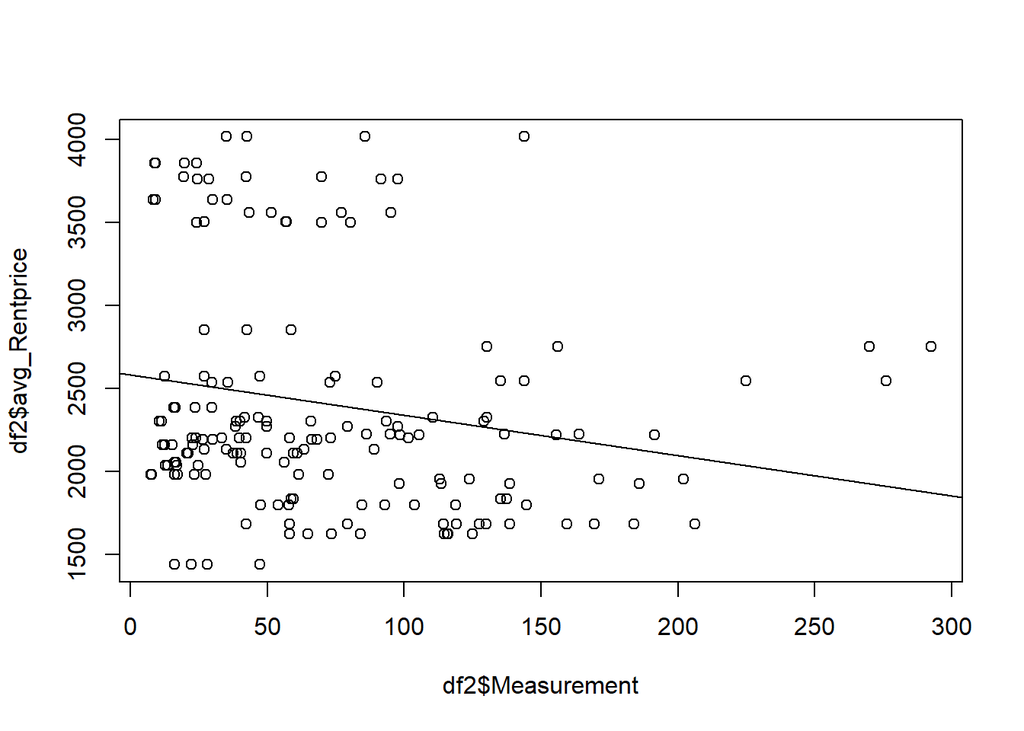

```r
abline(obs2)
```

PM2.5-Attributable Respiratory Hospitalizations (Adults 20 Yrs and Older)

```r
df8 <- filter(air_rent2, TypeofToxin == "PM2.5-Attributable Respiratory Hospitalizations (Adults 20 Yrs and Older)")

plot(df8$avg_Rentprice ~ df8$Measurement)
obs8 <- lm(df8$avg_Rentprice ~ df8$Measurement)
summary(obs8)
```

```
##
## Call:
## lm(formula = df8$avg_Rentprice ~ df8$Measurement)
##
## Residuals:
##     Min      1Q  Median      3Q     Max
## -1103.9  -463.9  -211.3   367.1  1752.8
##
## Coefficients:
##                 Estimate Std. Error t value Pr(>|t|)
## (Intercept)     2990.281    122.203  24.470  < 2e-16 ***
## df8$Measurement  -33.101      6.323  -5.235 4.94e-07 ***
## ---
## Signif. codes:  0 '***' 0.001 '**' 0.01 '*' 0.05 '.' 0.1 ' ' 1
##
## Residual standard error: 650 on 166 degrees of freedom
## Multiple R-squared:  0.1417, Adjusted R-squared:  0.1365
## F-statistic:  27.4 on 1 and 166 DF,  p-value: 4.936e-07
```

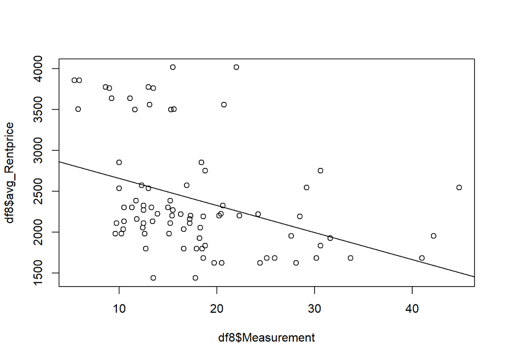

```r
abline(obs8)
```

While none of these models have strong linear relationships (the $R^2$ value for each is very close to 0), they are statistically significant variables (we know this since the P-values for each variable are well below 0.05). This implies there is a negative relationship between air quality and rent prices.

## Conclusion

Based on our findings, there is a statistically significant relationship between air quality and rent prices. It is safe to conclude that New York City neighborhoods with higher rent prices have less air pollutants. We cannot say which variable causes the other, but we can say this correlation is of interest to those in the NYC Environmental Department. Poor air quality, as we have seen, can lead to chronic diseases, particularly Asthma. This negatively affects people’s day to day lives. It is unjust that low-income communities should suffer from the effects of poor air quality.

Our findings might be of interest for future studies that look at the impact of air quality/pollution on human health such as the birth weight of children, children mortality and the elderly.